DS 6030 | Fall 2023 | University of Virginia

# Homework #9: Stacking and Boosting

Author

**Rose Eluvathingal Muttikkal**

Published

November 14, 2023

# Problem 1: Stacking for Kaggle

- You will need to register in Kaggle (its free)
- Read the details of the contest. Understand the data and evaluation function.
- Make at least one submission that uses **stacking or model averaging**.
- If you get a score on the public leaderboard of $\text{RMSE}<0.50$ (note RMSE is calculated on the log scale), you receive full credit, otherwise, you’ll lose 10 points.
  - I’ll allow [teaming](https://www.kaggle.com/c/house-prices-advanced-regression-techniques/team). Each team member can produce one component model and then use stacking or model averaging to combine predictions.
  - You don’t need to team, but must still combine multiple models. At least one of the component models should be boosting.
- Each person submit the following in Canvas:
  - Code (if teaming, your code and the shared stacking code)
  - kaggle name (or team name) so we can ensure you had a valid submission.
  - your score and current ranking on the kaggle leaderboard
- Top 5 scores get 2 bonus points
  - Teams will split their bonus points among team members

```r
library(dplyr)
library(purrr)
library(rpart)
library(rpart.plot)
library(ipred)
library(ggplot2)
```

### Data Prep

```r
train_path <- "/Users/rosee.m./Desktop/bookmarks/ds_stat_learn/StatLearning_HW9/house-prices-advanced-regression-techniques/train.csv"
test_path <- "/Users/rosee.m./Desktop/bookmarks/ds_stat_learn/StatLearning_HW9/house-prices-advanced-regression-techniques/test.csv"

# load data
train <- read.csv(train_path)
test <- read.csv(test_path)
test[is.na(test)] <- 0

# set NAs to 0
train[is.na(train)] <- 0
numeric_columns <- sapply(train, is.numeric) & names(train) != "SalePrice"

# Scale numeric variables
train[numeric_columns] <- scale(train[numeric_columns])

head(train,10)
```

```
      Id MSSubClass MSZoning LotFrontage LotArea Street Alley LotShape
1  -1.73     0.0733       RL      0.2128 -0.2071   Pave     0      Reg
2  -1.73    -0.8723       RL      0.6455 -0.0919   Pave     0      Reg
3  -1.73     0.0733       RL      0.2993  0.0735   Pave     0      IR1
4  -1.72     0.3098       RL      0.0686 -0.0969   Pave     0      IR1
5  -1.72     0.0733       RL      0.7609  0.3750   Pave     0      IR1
6  -1.72    -0.1631       RL      0.7898  0.3605   Pave     0      IR1
7  -1.72    -0.8723       RL      0.5013 -0.0434   Pave     0      Reg
8  -1.71     0.0733       RL     -1.6623 -0.0135   Pave     0      IR1
9  -1.71    -0.1631       RM     -0.1911 -0.4405   Pave     0      Reg
10 -1.71     3.1466       RL     -0.2199 -0.3103   Pave     0      Reg
   LandContour Utilities LotConfig LandSlope Neighborhood Condition1 Condition2
1          Lvl    AllPub    Inside       Gtl      CollgCr       Norm       Norm
2          Lvl    AllPub       FR2       Gtl      Veenker      Feedr       Norm
3          Lvl    AllPub    Inside       Gtl      CollgCr       Norm       Norm
```

[output cut: 117 more lines]

```r
set.seed(6030) # for reproducible results
train_indices <- sample(1:nrow(train), 0.8 * nrow(train))
train_data <- train[train_indices, ]
test_data <- train[-train_indices, ]
```

### EDA

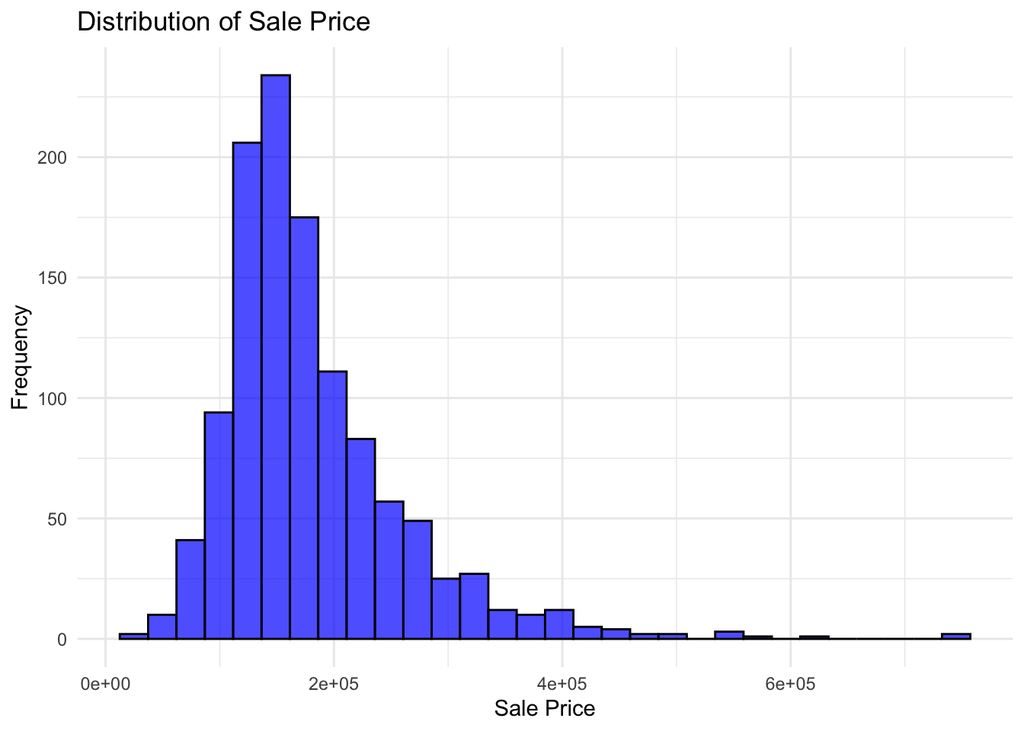

```r
# Assuming 'df' is your data frame and 'your_variable' is the variable you want to plot
ggplot(train_data, aes(x = SalePrice)) +
  geom_histogram(fill = "blue", color = "black", alpha = 0.7) +
  labs(title = "Distribution of Sale Price",
       x = "Sale Price",
       y = "Frequency") +
  theme_minimal()
```

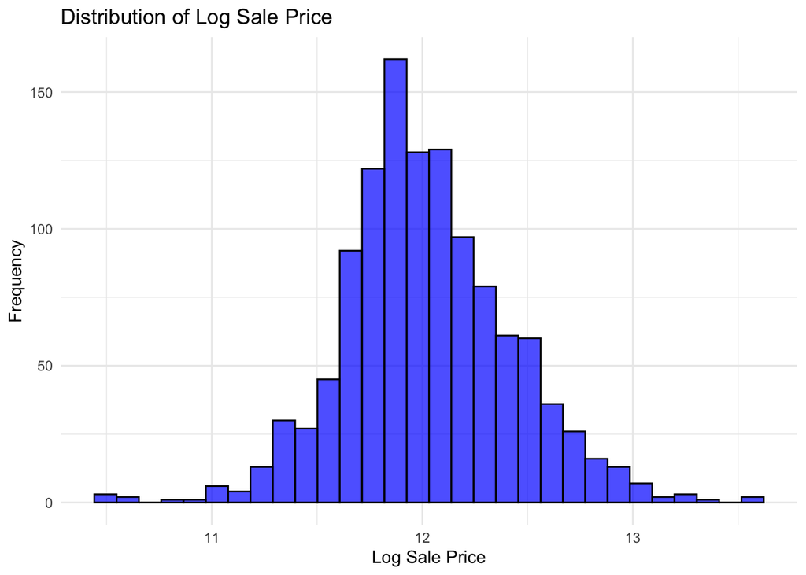

```r
ggplot(train_data, aes(x = log(SalePrice))) +
  geom_histogram(fill = "blue", color = "black", alpha = 0.7) +
  labs(title = "Distribution of Log Sale Price",
       x = "Log Sale Price",
       y = "Frequency") +
  theme_minimal()
```

### Set up x and y

```r
#Goal is to predict the log salary
train_data <- train_data %>%
  mutate(SalePrice=log(SalePrice)) %>%
  rename(Y=SalePrice)#convert to logSalary

test_data <- test_data %>%
  mutate(SalePrice=log(SalePrice)) %>% #convert to logSalary
  rename(Y=SalePrice)

#train data

#test data
X.test <- test_data %>%
  select(-Y)

Y.test <- test_data %>%
  select(Y)
```

### Align levels between training and test data

```r
align_levels <- function(train_data, test_data) {
  # Get the names of categorical variables
  categorical_vars <- names(train_data)[sapply(train_data, function(x) is.character(x) || is.factor(x))]

  # Loop through each categorical variable
  for (var in categorical_vars) {
    # Convert to factor if it's a character variable
    #if (is.character(train_data[[var]])) {
     # train_data[[var]] <- factor(train_data[[var]])
    #}
    #if (is.character(test_data[[var]])) {
     # test_data[[var]] <- factor(test_data[[var]])
    #}

    # Check unique levels in the training and test datasets
    unique_levels_train <- unique(train_data[[var]])
    unique_levels_test <- unique(test_data[[var]])

    #if (!identical(unique_levels_train, unique_levels_test)) {
        # Identify levels that are present in one but not the other
        additional_levels_train <- setdiff(unique_levels_train, unique_levels_test)
        additional_levels_test <- setdiff(unique_levels_test, unique_levels_train)

        # Combine all unique levels to ensure consistency
        all_levels <- union(unique_levels_train, unique_levels_test)

        # Update levels in the training and test datasets
        train_data[[var]] <- factor(train_data[[var]], levels = all_levels)
        test_data[[var]] <- factor(test_data[[var]], levels = all_levels)
    #}
  }
  # Return the updated datasets
  return(list(train_data = train_data, test_data = test_data))
}

# Example usage
aligned_data <- align_levels(train_data, X.test)
train_data <- aligned_data$train_data
X.test <- aligned_data$test_data
```

### Train simple tree

```r
set.seed(2019)
tree=rpart(Y~.,data=train_data)
summary(tree,cp=1)
```

```
Call:
rpart(formula = Y ~ ., data = train_data)
  n= 1168

       CP nsplit rel error xerror   xstd
1  0.4590      0     1.000  1.002 0.0505
2  0.0854      1     0.541  0.544 0.0309
3  0.0846      2     0.456  0.516 0.0299
4  0.0338      3     0.371  0.376 0.0223
5  0.0264      4     0.337  0.344 0.0220
6  0.0231      5     0.311  0.335 0.0213
7  0.0159      6     0.288  0.310 0.0191
8  0.0158      7     0.272  0.311 0.0191
9  0.0147      8     0.256  0.309 0.0191
10 0.0102      9     0.241  0.286 0.0180
11 0.0100     10     0.231  0.280 0.0180

Variable importance
 OverallQual Neighborhood    YearBuilt    ExterQual  GarageYrBlt  KitchenQual
          23           15           12           12           10            9
   GrLivArea    X1stFlrSF     MSZoning  TotalBsmtSF   GarageArea TotRmsAbvGrd
           3            2            2            2            2            1
  GarageCars   Foundation      LotArea    X2ndFlrSF   MSSubClass BedroomAbvGr
           1            1            1            1            1            1
    BsmtQual
           1

Node number 1: 1168 observations
  mean=12, MSE=0.159
```

```r
length(unique(tree$where))
```

```
[1] 11
```

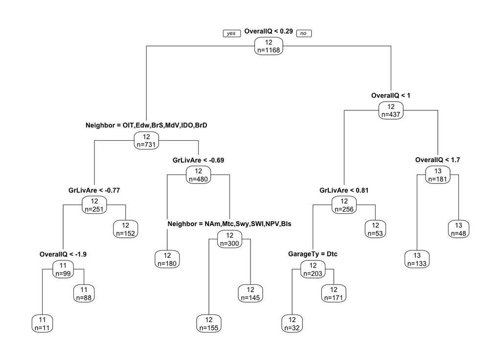

```r
# plot tree
prp(tree,type=1,extra=1,branch=1)
```

### Evaluate predictions from simple tree

```r
## predict

# Function to calculate RMSE
rmse <- function(predictions, actual) {
  sqrt(mean((predictions - actual)^2))
}
#must be log

rmse(predict(tree),train_data$Y) #training error
```

```
[1] 0.191
```

```r
rmse(predict(tree, X.test),Y.test$Y) #test error
```

```
[1] 0.221
```

### Tuning nbagg param for bagged tree

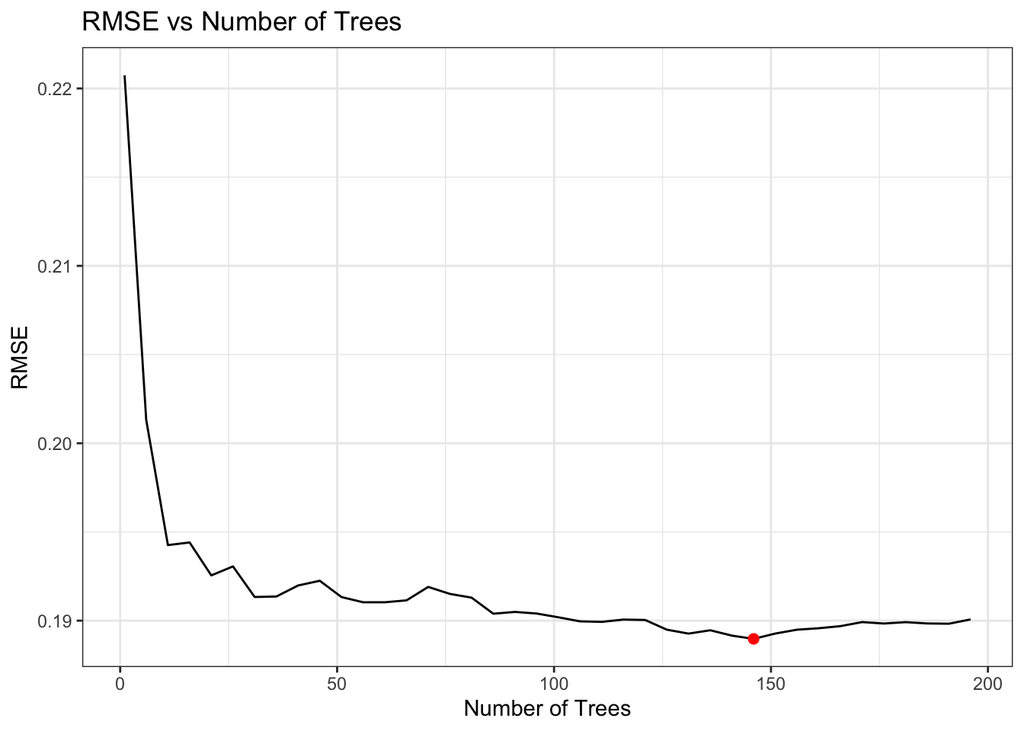

```r
# Function to train bagged tree model with different numbers of trees
train_bagged_model <- function(num_trees, train_data, test_data) {
  set.seed(2019)
  bag_tree <- bagging(Y ~ ., data = train_data, nbagg = num_trees)
  predictions <- predict(bag_tree, test_data)
  return(predictions)
}

# Create a sequence of the number of trees you want to try
num_trees_seq <- seq(1, 200, by = 5)

# Initialize an empty vector to store RMSE values
rmse_values <- numeric(length(num_trees_seq))

# Train models with different numbers of trees and calculate RMSE
for (i in seq_along(num_trees_seq)) {
  predictions <- train_bagged_model(num_trees_seq[i], train_data, X.test)
  rmse_values[i] <- rmse(predictions, Y.test$Y)
}

# Create a data frame for plotting
plot_data <- data.frame(num_trees = num_trees_seq, rmse = rmse_values)
# Find the minimum RMSE value and corresponding number of trees
min_rmse_index <- which.min(plot_data$rmse)
min_rmse_num_trees <- num_trees_seq[min_rmse_index]
min_rmse_value <- rmse_values[min_rmse_index]

# Plotting
ggplot(plot_data, aes(x = num_trees, y = rmse)) +
  geom_line() +
  geom_point(data = data.frame(num_trees = min_rmse_num_trees, rmse = min_rmse_value),
             aes(x = num_trees, y = rmse), color = "red", size = 2) +
  labs(title = "RMSE vs Number of Trees",
       x = "Number of Trees",
       y = "RMSE")
```

### Ideal nbagg value

```r
min_rmse_num_trees
```

```
[1] 146
```

### Train a bagged tree

```r
set.seed(2019)
bag_tree <- bagging(
  formula = Y ~ .,
  data = train_data,
  nbagg = 146,
  coob = TRUE )
bag_tree
```

```
Bagging regression trees with 146 bootstrap replications

Call: bagging.data.frame(formula = Y ~ ., data = train_data, nbagg = 146,
    coob = TRUE)

Out-of-bag estimate of root mean squared error:  0.179
```

### Evalutate prediction from bagged tree

```r
rmse(predict(bag_tree),train_data$Y)
```

```
[1] 0.179
```

```r
rmse(predict(bag_tree, X.test),Y.test$Y)
```

```
[1] 0.189
```